# Stats240P-FinalProject

Interpreting the p-values:

```r
# Install and load the necessary packages (if not already installed)
library(tidyverse)
library(factoextra)
```

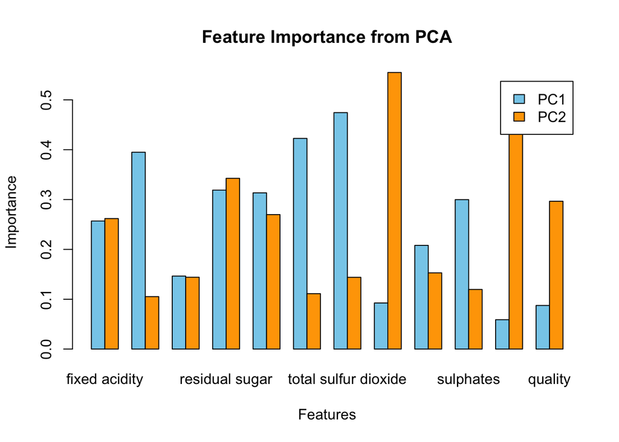

```r
# Extract numeric columns for PCA
numeric_columns <- select_if(wine_data, is.numeric)

# Perform PCA
pca_result <- prcomp(numeric_columns, scale. = TRUE)

# Get importance of each feature
importance <- get_pca_var(pca_result)$contrib

# Get feature importance
importance <- abs(pca_result$rotation[, 1:2])  # Selecting the first two principal components

# Create a bar plot of feature importance
barplot(t(importance), beside = TRUE, col = c("skyblue", "orange"),
        main = "Feature Importance from PCA",
        xlab = "Features",
        ylab = "Importance",
        legend.text = c("PC1", "PC2"))
```

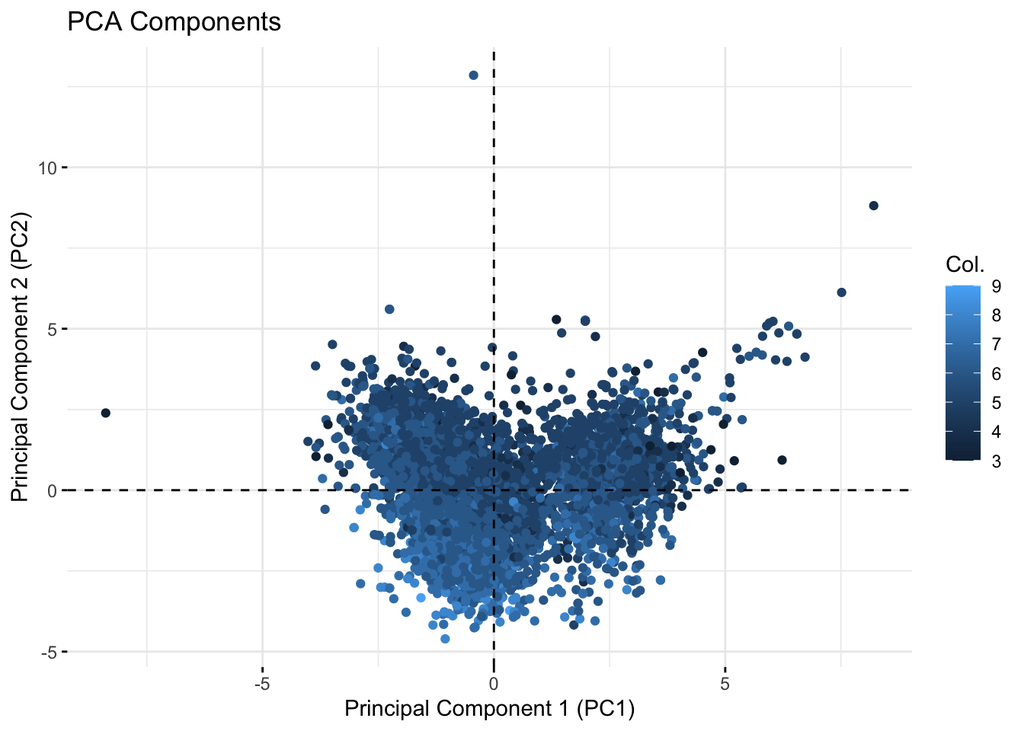

```r
pca_result$quality <- wine_data$quality
# Plot the PCA components
fviz_pca_ind(pca_result, label = "none", geom = "point",
             col.ind = pca_result$quality,
             title = "PCA Components",
             xlab = "Principal Component 1 (PC1)",
             ylab = "Principal Component 2 (PC2)")
```

```r
print(importance)
```

```
##                             PC1       PC2
## fixed acidity        0.25692873 0.2618431
## volatile acidity     0.39493118 0.1051983
## citric acid          0.14646061 0.1440935
## residual sugar       0.31890519 0.3425850
## chlorides            0.31344994 0.2697701
## free sulfur dioxide  0.42269137 0.1111788
## total sulfur dioxide 0.47441968 0.1439475
## density              0.09243753 0.5549205
## pH                   0.20806957 0.1529219
## sulphates            0.29985192 0.1196342
## alcohol              0.05892408 0.4927275
## quality              0.08747571 0.2966009
```

Based on the provided importance scores for the first two principal components (PC1 and PC2), we can interpret the importance of the features as follows:

PC1:

- The features with higher absolute values in PC1 are volatile acidity (0.3949), free sulfur dioxide (0.4227), total sulfur dioxide (0.4744), and residual sugar (0.3189).
- These features have a strong positive influence on PC1 and are important for explaining the variance captured by PC1.
- It suggests that high levels of volatile acidity, free sulfur dioxide, total sulfur dioxide, and residual sugar contribute to the variation captured by PC1.

PC2:

- The features with higher absolute values in PC2 are density (0.5549), alcohol (0.4927), and quality (0.2966).
- These features have a strong positive influence on PC2 and are important for explaining the variance captured by PC2.
- It indicates that higher density, alcohol content, and quality scores contribute significantly to the variation captured by PC2.

Based on this interpretation, the important features for explaining the variance in the dataset are volatile acidity, free sulfur dioxide, total sulfur dioxide, residual sugar, density, alcohol, and quality.

```r
# Fit a linear regression model with all features
full_model <- lm(quality ~ ., data = wine_data)

# Define a function to calculate AIC
calculate_aic <- function(model) {
  n <- length(model$residuals)
  k <- length(model$coefficients)
  aic <- n * log(sum(model$residuals^2) / n) + 2 * k
  return(aic)
}

# Define a function to calculate BIC
calculate_bic <- function(model) {
  n <- length(model$residuals)
  k <- length(model$coefficients)
  bic <- n * log(sum(model$residuals^2) / n) + log(n) * k
  return(bic)
}

# Calculate AIC, BIC, and R-squared for the full model
full_model_aic <- calculate_aic(full_model)
full_model_bic <- calculate_bic(full_model)
full_model_r_squared <- summary(full_model)$r.squared

# Create a vector to store AIC, BIC, and R-squared values for each model
model_comparison <- data.frame(Features = "All", AIC = full_model_aic, BIC = full_model_bic, R_squared = full_model_r_squared)

# Loop through each feature and build models with subsets of features
for (i in 2:(ncol(wine_data)-1)) {
  feature_subset <- combn(names(wine_data)[-ncol(wine_data)], i)
  for (j in 1:ncol(feature_subset)) {
    subset_model <- lm(quality ~ ., data = wine_data[, c("quality", feature_subset[, j])])
    subset_model_aic <- calculate_aic(subset_model)
    subset_model_bic <- calculate_bic(subset_model)
    subset_model_r_squared <- summary(subset_model)$r.squared

    # Append the AIC, BIC, and R-squared values to the model comparison dataframe
    model_comparison <- rbind(model_comparison,
                              data.frame(Features = paste(feature_subset[, j], collapse = ", "),
                                         AIC = subset_model_aic,
                                         BIC = subset_model_bic,
                                         R_squared = subset_model_r_squared))
  }
}

# Sort the model comparison dataframe by AIC in ascending order
model_comparison <- model_comparison[order(model_comparison$AIC), ]

# Print the best model with the lowest AIC
best_model <- model_comparison[1, ]
print(best_model)
```

```
##                                                                                                                                          Features
## 4080 type, fixed acidity, volatile acidity, residual sugar, chlorides, free sulfur dioxide, total sulfur dioxide, density, pH, sulphates, alcohol
##            AIC       BIC R_squared
## 4080 -4022.657 -3941.308 0.2964677
```

AIC score suggests dropping citric acid as features, consistent with the high p-value showing insignificant.

```r
# Install and load the necessary packages (if not already installed)

library(randomForest)
```

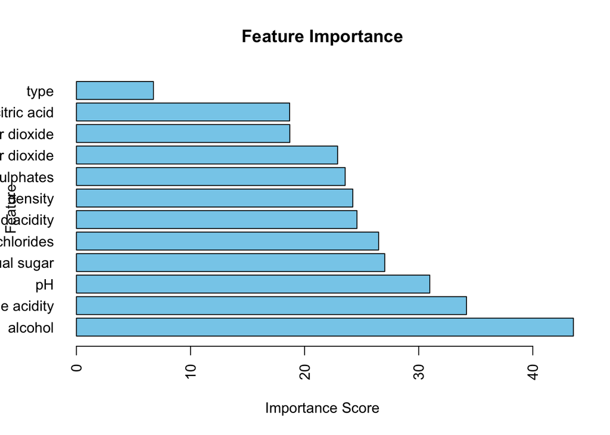

```r
# Separate the features and target variable
X <- wine_data[, -ncol(wine_data)]  # Exclude the target variable column

# Convert the target variable to a factor (replace "target_variable" with your actual column name)
y <- as.factor(wine_data$quality)

# Perform feature importance using Extra Trees Classifier
model <- randomForest(X, y, ntree = 100, importance = TRUE)
importance <- importance(model)

# Sort the feature importance scores in descending order
sorted_importance <- importance[order(importance[, 3], decreasing = TRUE), ]

# Plot the feature importance
barplot(sorted_importance[, 3], horiz = TRUE, names.arg = row.names(sorted_importance),
        ylab = "Feature", xlab = "Importance Score", col = "skyblue",
        main = "Feature Importance", las = 2)
```

```r
library(randomForest)

# Assuming you have your dataset stored in a data frame called 'data'
X <- wine_data[, -ncol(wine_data)]
y <- as.factor(wine_data$quality)  # Target variable


# Create an instance of Extra Trees Classifier
model <- randomForest(X, y)

# Get the feature importances
importances <- importance(model)

print(importances)
```

```
##                      MeanDecreaseGini
## type                         14.89301
## fixed acidity               327.10515
## volatile acidity            431.99574
## citric acid                 348.28527
## residual sugar              370.54897
## chlorides                   378.02393
## free sulfur dioxide         375.90486
## total sulfur dioxide        395.39268
## density                     443.71850
## pH                          364.93560
## sulphates                   377.31239
## alcohol                     532.95233
```

Interpreting the table:

- The higher the MeanDecreaseGini value, the more important the feature is in predicting the target variable.
- Features with higher scores have a greater impact on the model’s performance and contribute more to reducing the impurity in the decision tree.
- In this case, the alcohol feature has the highest importance score, indicating it is considered the most influential feature for predicting the target variable.
- Other features such as sulphates, volatile acidity, density, and total sulfur dioxide also have relatively high importance scores, suggesting they have a significant impact on the model’s predictions.
- On the other hand, features like fixed acidity, and citric acid have lower importance scores, indicating they have less influence on the model’s predictions.

Overall, the table provides insights into the relative importance of each feature in the dataset based on the MeanDecreaseGini metric. These scores can guide feature selection and help identify the most relevant features for building predictive models.

### Q2. Measure the average value of the various attributes that clearly classify the wine as a good quality wine.

To measure the average value of various attributes that clearly classify wine as good quality, you can filter the dataset based on a specific threshold for the quality variable. In this case, assuming a binary classification where a quality score of 7 or higher represents good quality wine, we can calculate the average values of attributes for those wines.

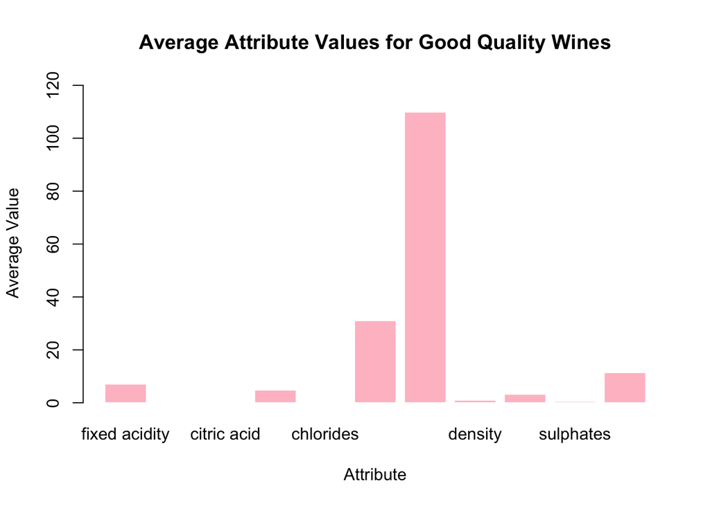

```r
# Filter wines with quality score of 7 or higher
good_quality_wines <- wine_data[wine_data$quality >= 7, ]

# Drop the "type" column
good_quality_wines <- good_quality_wines[, -which(names(good_quality_wines) == "type")]

# Calculate the average values of attributes for good quality wines
average_attributes <- colMeans(good_quality_wines[, -ncol(good_quality_wines)])

# Create a bar plot of average attribute values
barplot(average_attributes,
        main = "Average Attribute Values for Good Quality Wines",
        xlab = "Attribute",
        ylab = "Average Value",
        col = "pink",
        border = "white",
        ylim = c(0, max(average_attributes) * 1.1))
```

```r
# Display the average values
print(average_attributes)
```

```
##        fixed acidity     volatile acidity          citric acid
##           7.08570869           0.28916993           0.33462803
##       residual sugar            chlorides  free sulfur dioxide
##           4.82772122           0.04457557          31.05520752
## total sulfur dioxide              density                   pH
##         109.89115114           0.99302684           3.22765074
##            sulphates              alcohol
##           0.54148786          11.43335944
```